# PredictifyR | Word Prediction Model

John James

07 April, 2017

# Abstract

# Introduction

Word prediction language models are essential components within a range of natural language processing (NLP) applications such as Augmented and Alternative Communication (AAC), statistical machine translation, speech recognition [Bahl1983], handwriting recognition, word-sense disambiguation, spelling correction and predictive text entry. Mobile device applications, which are the focus of this report, require language models that are accurate, fast, and compact. The statistical n-gram language model is the dominant technology; yet, more sophisticated models are being developed which are able to exploit other natural language phenomena, including syntactic, semantic, and morphological structures [Cavalieri2015]. Innovative interpolation methods to integrate language models are also being developed with interesting results.

Through a systematic evaluation of selected word prediction strategies, algorithms and language models of various sizes, this work seeks to determine which algorithms best meet the performance imperatives of the mobile device predictive text entry application. Statistical n-Gram techniques, syntactic modeling approaches, semantic-based models, and classification-based techniques were evaluated from prediction accuracy, model size, and speed perspectives.

The remainder of this section provides an introduction to probabilistic word prediction and n-Gram language models. Section 2 surveys related work in terms of the best performing n-Gram based-models and smoothing techniques, models which integrate syntactic information, semantic approaches and learning-classification based approaches. Section 3 reveals the details of the experimental methodology including corpus analysis, preprocessing, and sampling, as well as language model implementation and parameter selection. Section 4 outlines the results of the study and finally, section 5 summarizes the most important conclusions of the work.

## Probabilistic Word Prediction

The problem of predicting the next word, given a sentence or some history, begs the question, “what is the most probable word?”, given the history. Language models assign probabilities to words and sequences of words, based upon observed frequencies in corpus of text. Theoretically, one might estimate the probability that word, ${w_n}$, is the next word in a sequence of words (${w_1}$,${w_2}$, …, $w_{n-1}$) (or the probability of the sequence (${w_1}$,${w_2}$, …, $w_{n}$) by counting the number of times the sequence occurs and normalizing that by the number of times the history occurs as follows:

$$P({w_1},{w_2}, ..., w_{n}) = \frac{C({w_1},{w_2}, ..., w_{n})}{C({w_1},{w_2}, ..., w_{n-1})}$$
Even with a corpus as large as the internet, new language and sequences are created all the time and it may not be possible to estimate such long sequences. Using the chain rule of probabilities, we can decompose the problem into a list of conditional probabilities as follows [Jurafsky2016]:
$$P({w_1^n}) = P({w_1})P({w_2}|{w_1})P({w_3}|{w_1^2})...P({w_n}|{w_1^{n-1}})$$
Still one is left with estimating the probability of long sequences.

### N-Grams

Russian mathematician Andrey Markov observed that the language production is a “memoryless” stochastical process where the conditional probability distribution of A future word depends only upon the present word [Markov1906]. Thus one can estimate the probability of word given its entire history by calculating the probability of the word given the prior word. Thus:

$$P({w_n}|{w_1^{n-1}}) \approx P({w_n}|{w_{n-1}})$$
The language model that estimates the probability using only the previous word is called the bigram model. This can be generalized to the trigram model that takes into account, the previous two words and the N-gram model that considers the previous N-1 words. Thus the general equation for the N-gram approximation of the conditional probability of the next word in a sentence is [Jurafsky2016]:
$$P({w_n}|{w_1^{n-1}}) \approx P({w_n}|{w_{n-N+1}^{n-1}})$$
To calculate these N-gram probabilities, one performs a **maximum likelihood estimation** or **MLE** as follows:
$$P({w_n}|{w_{n-N+1}^{n-1}}) = \frac{C({w_{n-N+1}^{n-1}},{w_n})}{C({w_{n-N+1}^{n-1}})}$$
Equation 1 uses the relative frequency of a particular sequence and its prefix to estimate N-gram probabilities.

### Evaluating Language Models

Assuming a researcher has the resources and time, the true measure of the performance of a language model is obtained by conducting an end-to-end **extrinsic evaluation** of the model within an application [Jurafsky2016]. **Intrinsic evaluations**, on the other hand, provide performance metrics independent of any application. Given a training set, upon which the language model is trained, a researcher can measure the performance on an unseen test set by evaluating the degree to which the model models the test set. This can be performed by calculating the probability of the test set, but this metric is rarely used in practice. **Perplexity**, the inverse probability of the test set, normalized by the number of words, is the metric commonly used in intrinsic evaluations and is defined as follows:

$$PP(W) = \sqrt[N]{\frac{1}{P(w_1 w_2 ... w_N)}} = \sqrt[N]{\displaystyle\prod_{i=1}^{N}\frac{1}{P(w_i | w_1...w_{i-1})}}$$
where a test set $W = w_1 w_2 ... w_N$ [Jurafsky2016].

Multiplying all the probabilities of all the N-gram together can result in numeric underflow. Instead one works in log space, adding the log of the probabilities together, then taking the average of the sum of the log probabilities over the entire corpus. Lastly, we take the negative of the corpus log probability and raise that to the power of 2, resulting in a positive number. The final equation is as follows:

$$Perplexity = 2^{-{1/N}{\displaystyle\sum_{i=1}^N{log p({s_i})}}}$$

Note that perplexity calculation fails with zeros in the denominator if a word or N-gram sequence from the test set doesn’t occur in the training set. The next section provides techniques for dealing with such out-of-vocabulary (OOV) words and sequences.

### Smoothing

Smoothing refers to a class of techniques used to deal with unseen sequences by discounting probability mass from more frequent sequences and giving it to events sequences. One of the most commonly used and best performing N-gram smoothing techniques are the Interpolated Kneser-Ney [Kneser1995a] and the Modified Kneser-Ney smoothing algorithms [Chen1998]. This section begins with a review of the absolute discounting technique from which the Kneser-Ney algorithms were derived.

#### Absolute Discounting

Absolute discounting [Ney1994] subtracts a fixed discount $d$ typically less than 1, from each count. Very high counts have good probability estimates and are not affected by the discount as much as smaller counts with relatively unreliable estimates. Interpolated absolute discounting improves the algorithm by interpolating lower order models as follows:

$$P_{abs}(w_i | w_{i-n+1}^{i-1}) = \frac{max\left\{c(w_{i-n+1}^{i})-D,0\right\}} {c(w_{i-n+1}^{i-1})}+\lambda(w_{i-n+1}^{i-1})P_{abs}(w_i | w_{i-n+2}^{i-1})$$
To force the distribution to sum to 1:
$$\lambda(w_{i-n+1}^{i-1}) = \frac{D}{{c(w_{i-n+1}^{i-1})}} N_{1+}(w_{i-n+1}^{i-1}\bullet)$$
where $N_{1+}$ is the number of words that have one or more counts and $N_{1+}(w_{i-n+1}^{i-1}\bullet) = |\left\{w_i : c(w_{i-n+1}^{i} w_i) > 0\right\}|$ is the number of unique words that follow the sequence. $D$ is estimated as follows:
$$D = \frac{n_1}{n_1 + 2n_2}$$
where $n_1$ and $n_2$ are the total number of n-grams with exactly one and two counts, respectively [Chen1998].

#### Kneser-Ney Smoothing

Kneser-Ney smoothing improves on interpolated absolute discounting by constructing the lower-order distribution that is combined with the higher-order distribution in a novel manner. In interpolated absolute discounting, the lower-order distribution is based upon a smoothed version of the lower-order maximum likelihood estimation. Rather than considering lower-order n-gram frequencies, the Kneser-Ney algorithm bases the lower-order distribution on the number of n-gram prefixes the word follows. In other words, the algorithm counts how often the word exists as a novel continuation of the n-gram prefix [Chen1998]. There are three Kneser-Ney formulations: one for the **highest** order N-gram distributions $n$ where $n=N$, a second for **higher** distributions $n$ where $1 < n < N$, and a third for the unigram distribution $n = 1$. The recursive formulation for the **highest** order distribution is as follows:

$$P_{KN}(w_i | w_{i-n+1}^{i-1}) = \frac{max\left\{c(w_{i-n+1}^{i})-D,0\right\}}{ c(w_{i-n+1}^{i-1})}+\frac{D}{c(w_{i-n+1}^{i-1})} N_{1+}(w_{i-n+1}^{i-1}\bullet)P_{KN}(w_i | w_{i-n+2}^{i-1})$$
where $\begin{equation}N_{1+}(w_{i-n+1}^{i-1}\bullet) = |\left\{w_i : c(w_{i-n+1}^{i} w_i) > 0\right\}|\end{equation}$

The recursive formulation for the **higher** order distribution $n$ where $1 < n < N$ is as follows:

$$\begin{equation}
P_{KN}(w_i | w_{i-n+1}^{i-1}) = \frac{max\left\{N_{1+}(\bullet w_{i-n+1}^{i})-D,0\right\}}{N_{1+}(\bullet w_{i-n+1}^{i-1}\bullet)}+\frac{D}{N_{1+}(\bullet w_{i-n+1}^{i-1}\bullet)} N_{1+}(w_{i-n+1}^{i-1}\bullet)P_{KN}(w_i | w_{i-n+2}^{i-1})
\end{equation}$$
where $\begin{equation}N_{1+}(w_{i-n+1}^{i}\bullet) = |\left\{w_{i-n} : c(w_{i-n}^{i} w_i) > 0\right\}|\end{equation}$ $\begin{equation}N_{1+}(\bullet w_{i-n+1}^{i-1}\bullet) = |\left\{(w_{i-n}, w_i) : c(w_{i-n}^{i}) > 0\right\}| = \displaystyle\sum_{w_i} N_{1+}(\bullet w_{i-n+1}^{i})\end{equation}$

The formulation for the **lowest** unigram distribution is as follows:

$$\begin{equation}
P_{KN}(w_i) = \frac{N_{1+}(\bullet w_{i})}{N_{1+}(\bullet\bullet)}
\end{equation}$$
where $N_{1+}(\bullet w_i) = |\left\{w_{i-1} : c(w_{i-1}^{i}) > 0\right\}|$ $N_{1+}(\bullet \bullet) = |\left\{(w_{i-1}, w_i) : c(w_{i-1}^{i}) > 0\right\}| = \displaystyle\sum_{w_i} N_{1+}(\bullet w_{i})$

#### Modified Kneser-Ney Smoothing

Modified Kneser-Ney Smoothing is the best performing version of the group. Instead of using a single discount $D$ for all non-zero counts, this version uses three different discount parameters $D_{n,1}$,$D_{n,2}$, and $D_{n,3+}$ for each N-Gram order ($1 < n \leq N$). The equation for the **higher** order N-Grams is as follows:

$$\begin{equation}
P_{MKN}(w_i | w_{i-n+1}^{i-1}) = \frac{max\left\{N_{1+}(\bullet w_{i-n+1}^{i})-D_n(c(w_{i-n+1}^i)),0\right\}}{N_{1+}(\bullet w_{i-n+1}^{i-1}\bullet)}+\lambda_{low}(w_{i-n+1}^{i-1})P_{MKN}(w_i | w_{i-n+2}^{i-1})
\end{equation}$$

where

$$D_n(c) =
\begin{cases}
0 & \quad \text{if } c=0\\
D_{n,1} & \quad \text{if } c=1\\
D_{n,2} & \quad \text{if } c=2\\
D_{n,3+} & \quad \text{if } c\geq3\\
\end{cases}$$
The normalized discount $\lambda_{low}(w_{i-n+1}^{i-1})$ for the **higher** order N-Gram distributions is:
$$\lambda_{low}(w_{i-n+1}^{i-1}) = \frac{D_{n,1} N_1(w_{i-n+1}^{i-1}\bullet) + D_{n,2} N_2(w_{i-n+1}^{i-1}\bullet) + D_{n,3+} N_{3+}(w_{i-n+1}^{i-1}\bullet)}{N_{1+}(\bullet w_{i-n+1}^{i-1}\bullet)}$$
where $N_1(w_{i-n+1}^{i-1}\bullet)$, $N_2(w_{i-n+1}^{i-1}\bullet)$, and $N_{3+}(w_{i-n+1}^{i-1}\bullet)$ are the unique one word contexts in which the sequence appears, precisely once, twice, or 3 or more times, respectively.

Analogously, the equation for the **highest** order N-Gram distribution uses absolute counts for the highest level discounted probability estimate and is as follows:

$$\begin{equation}
P_{MKN}(w_i | w_{i-n+1}^{i-1}) = \frac{max\left\{c(w_{i-n+1}^i)-D_n(c(w_{i-n+1}^i)),0\right\}}{c(w_{i-n+1}^i)}+\lambda_{high}(w_{i-n+1}^{i-1})P_{MKN}(w_i | w_{i-n+2}^{i-1})
\end{equation}$$

where the normalized discount $\lambda_{high}(w_{i-n+1}^{i-1})$ for the **highest** order N-Gram distributions is:

$$\lambda_{high}(w_{i-n+1}^{i-1}) = \frac{D_{n,1} N_1(w_{i-n+1}^{i-1}\bullet) + D_{n,2} N_2(w_{i-n+1}^{i-1}\bullet) + D_{n,3+} N_{3+}(w_{i-n+1}^{i-1}\bullet)}{c(w_{i-n+1}^{i-1})}$$

## Syntactic Word Prediction

Syntactic word prediction aims to predict the most likely next word, or word in sequence, based upon its syntactical relationship with its context. Part-of-speech (POS) tags of all words are identified in a corpus and the system combines this syntactic knowledge with the syntactical structure of the language to make predictions [Ghayoomia]. Statistical syntax and rule-based grammars are the two general methods that will be introduced in this paper.

### Statistical Syntax

The statistical syntax approach assigns probabilities to candidate words by estimating the probability of having that word, with its POS tag, in its current position. Some approaches consider the current word and its POS tag, as well as the POS tag of the preceding word(s). Using linear interpolation techniques, a system can predict the next POS, based upon previous POS(s), then the most likely word given the predicted POS, then combine that with the probability of the word, given its previous word. Experiments with such “integrated” models have shown them to lower perplexity and increase key stroke savings over traditional word-based N-gram models.

### Rule-Based Grammar

## Semantic Prediction

## Classification-Based Word Prediction

The next section summarizes work related to nGram based probabilistic models as well as innovations in syntactic, semantic,and classification based word prediction models.

# Related Work

In this section, several approaches to word prediction are surveyed. This is not intended to be an exhaustive review, rather, the focus is on novel approaches and those considered state-of-the-art in word prediction. First, statistical n-gram based approaches and language models (LMs) are examined. Next, syntactic, POS-based models are surveyed. Next, semantic modeling approaches to word prediction are summarized. Lastly, learning-classification approaches are surveyed.

## Statistical Word Prediction

### CMU-Cambridge Statistical Language Modeling Toolkit

Originally released in 1994, by Philip Clarkson of Cambridge University and Ronald Rosenfeld of Carnegie Melon University, the CMU-Cambridge Statistical Language Model Toolkit is a collection of Unix software tools for developing and testing traditional bigram and trigram language models [Clarkson1997]. It now supports $N$-gram models for any value of $N$. The model currently supports Good-Turing [10.2307/2333344] discounting with backoff, linear discounting, absolute discounting, and Witten-Bell [Witten:2006:ZPE:2263404.2271157] discounting. Both closed and open vocabulary models are supported. The closed vocabulary model makes no accommodation for OOV tokens, which cause the system to error. The open vocabulary model maps all OOV words in the training set to a single symbol and allows OOV tokens to be defined in a test set. Multiple models may be combined with linear interpolation and evaluated using the perplexity statistic [Clarkson1997].

### MIT Language Model Toolkit

The MIT Language Model Toolkit (MITLM) supports the estimation of statistical N-gram language models involving iterative estimation of smoothing, interpolation, and N-gram weighting parameters. It’s default model is the trigram with modified Kneser-Ney smoothing, although traditional Kneser-Ney with discount tuning, and other N-gram orders are also supported. Linear interpolation is supported with tunable weights. Closed and open vocabulary models are supported.

### VariKN

The VariKN [Silvola] language model is a toolkit for training n-gram language models using absolute discounting, interpolated Kneser-Ney smoothing, revised Kneser pruning and Kneser-Ney growing which enables very high-order N-grams. Absolute discounting and interpolated Kneser-Ney smoothing was introduced in the prior section. In the **revised Kneser Pruning technique**, the model is revised after each N-gram has been pruned, the back-off coefficients and distributions are updated, and the impact on the log probability *by the N-gram count* (rather than the probability estimated *by the model*), is assessed [Siivola2007a]. If the decrease in log probability is greater than the pruning threshold, the N-gram is restored. Analogously, the **Kneser-Ney Growing algorithm incrementally creates a variable length model, rather than computing all N-grams up to a certain order, then pruning. The algorithm starts with an interpolated 1-g Kneser-Ney model, adding each N-gram $w$ at order $k=1$, then adds each $k+1$ N-gram $w_1$,$w$ to the model only if it they meet a cost criterion. Since the model is grown one distribution at a time, individual unnecessary N-grams are pruned. The costs criterion consists of the cost of encoding the training data - the log probability of the training data, and the cost of coding the N-gram model - the number of bits required to store each float with given precision. Experiments on Finnish and English text corpora have shown that the revised Kneser-Ney algorithm gives significantly lower cross-entropies when compared to the previous pruning algorithms and the Kneser-Key Growing algorithm further reduces perplexity [Siivola2007a].

The following language model toolkits are aimed optimizing storage and processing requirements for very large N-grams. This experiment does not seek to propose any computational improvements and so the following models are summarized to provide a sense of the current direction of innovation in the language modeling industry.

### IRST Language Modeling Toolkit

IRSTLM, the IRST Language Modeling Toolkit, features algorithms and data structures for estimating, storing, and accessing very large N-gram language models with billions of N-grams on conventional machines. Stored in the conventional ARPA format, IRSTLM performs N-gram collection and storage using efficient data structures and distributed processing. Standard interpolation as well as Witten-Bell [Witten:2006:ZPE:2263404.2271157] and improved Kneser-Ney smoothing algorithms are supported [Federico2008]. Their model data structure implements a forward trie, in which each node contains a sorted array of entries and words are looked up in their natural left-to-right order. This with a binary file format with memory mapping offers lower memory consumption and caching to increase speed and quantization [Heafield2011].

### Berkeley LM

The Berkeley LM [Pauls2011] is a Java-based library for the efficient storage and estimation of very large N-Gram language models in memory. Encoding techniques, direct address caching, and changes to the language model interface, enables the system to store the 4 billion N-grams of the Google WebIT [Brants2006] corpus with associated counts in 10 GB of memory. Implicit tries [Whittaker2001], a more compact implementation of traditional tries structures, encoded nodes in tries into entries in arrays with enough bits to index all the words in the model. Context encoding, based upon the work of [Hsu2008], encodes an N-gram with its context such that the pair can be stored in a single 64-bit integer. Experiments have shown improvements in query speed over SRILM and compression rates against state-of-the-art lossy compression [Pauls2011].

### RandLM

RandLM is a space-efficient N-gram based language model built using Bloom filters (BF), a randomized data structure fall with space requirements that are significantly below lossless information-theoretic lower bounds [Talbot2007]. Standard as well as Witten-Bell [Witten:2006:ZPE:2263404.2271157] and Kneser-Ney smoothing algorithms are implemented. Experiments have demonstrated the RandLM to substantially reduce memory requirements of very large N-gram models.

### KenLM

The KenLM [Heafield2011], lead by Kenneth Heafield of Carnegie Mellon University, is one of the fastest open-source language model toolkits used in available. Estimation is based upon modified Kneser-Ney smoothing without pruning. It supports multi-core processing and features two data structures for efficient language model queries. The PROBING data structure, designed for speed, uses linear probing hash tables. The TRIE data structure reduces memory consumption with with bit-level packing, sorted records, interpolation search, and optional quantization. Experimenets have shown that it is faster and uses less memory than SRILM and IRSTLM.

### The OpenGrm NGram Library

The OpenGrm NGram library is used to make and modify n-gram language models encoded as weighted finite-state transducers (FSTs). Functionality includes counting, smoothing, pruning, applying, and evaluating models. It supports 1-gram through 5-gram counts, smoothing using Katz [Katz1987] Kneser-Ney [Kneser1995], and (default) [Witten-Bell Witten:2006:ZPE:2263404.2271157]. It also provides support for distributed computation [Rossenstock].

## Semantic Modeling

## Learning-Classification Approaches

## Mixed Language Models

### SRI Language Modeling Toolkit (SRILM)

The SRI Language Modeling Toolkit [Stolcke2002], by SRI International, Menlo Park, CA, is a collection of C++ libraries, executables, and scripts that support language model estimation and evaluation for us in speech recognition, statistical tagging and segmentation, and machine translation applications. Since most language models in SRILM are N-gram based, it supports “theoretically” any order N-gram model. SRILM supports an array of standard smoothing and discounting algorithms such as Good-Turing, absolute, Witten-Bell, Jelinek-Mercer smoothing, and original and modified Kneser-Ney. Users can select an optional predefined vocabulary to limit or augment the words from the training data. Out-of-vocabulary words can be ignored or treated as a special “unknown word” token.

In addition to the standard word-based N-gram models, SRILM implements and integrates several other LMs. **Class-based models** incorporate domain knowledge such as word classes. Word classes can be manually created or learned using bigram statistics. Dynamic programming is used to disambiguate words that belong to multiple classes. **Cache models** assign non-zero probabilities to recent words to capture the tendency of words to reoccur over short time spans [DeMori1996]. These models are typically interpolated with standard n-gram models to improve predictive performance. **Skip language models** probabilistically skip words in the LM history to include more distant words. The skipping probabilities associated with each word are estimated using expectation minimalization. SRILM has implemented **factored language models** (FLMs) proposed by Bilmes and Kirchoff [Bilmes2003] which represents words as discrete features. This technique has applicability to languages with complex morphology such as Arabic [Vergyri2004].

Several methods for N-gram model integration have been implemented [Stolcke2011]. Two or more **dynamically interpolated LMs** can be combined such that the interpolation weights reflect the likelihood of the model given n-gram history. **Unigram marginal adaptation** [Kneser1997] integrates an existing Ngram language model with unigram statistics from an adaptation set by scaling the N-gram probabilities to conform to the unigram distribution. **Log-linear interpolation** of LMs [Klakow1998a] is “…similar to standard linear interpolation except that probabilities are combined multiplicatively rather than additively.” [Stolcke2011]

# Experimental Methodology

The following experiments were designed to address three key questions. How can syntactic and semantic knowledge be integrated into an N-gram based probabilistic model? Given a baseline modified Kneser-Ney N-gram model, what are the word prediction performance improvements associated with the integrated models? Lastly, what is the impact of lexical size on performance? This section is a detailed accounting of the experimental methodology used to address these questions. Getting the preliminaries out of the way, this section begins with an overview of the software and hardware environment for the experiment. Next, this section summarizes the corpus audit and outlines the data cleaning and corpus design processes. Once the data are split into training, validation, and test sets, various language models are implemented and evaluated. Source code is available in the appendix and can be forked from https://github.com/j2scode/PredictifyR.

## Corpus

Mobile texting, Augmented and Alternative Communication (AAC), intelligent word processing, speech recognition, and machine translation are among the varied applications of the word prediction task. Statistical methods of word prediction rely on language models that encode automatically obtained linguistic knowledge from corpora. Model performance, therefore, correlates with the degree to which the corpora upon which the language models are built, model the linguistic and lexical characteristics of the language for which the word prediction algorithms will be used. This project’s deliverable is a fast, compact, and intelligent word prediction application for the mobile texting application. As such, the language models must be built upon a corpus that reflects the diversity of settings, situational parameters, and therefore, lexical features and linguistic characteristics of the mobile texting language.

The corpus used for this project was obtained from the HC Corpora website Appendix C 1, a collection of freely available texts comprised of over 2.5 billion words from 67 languages (Christensen 2016). The English language corpus, consisting of approximately 70 million words across three registers: news, blogs, and twitter feeds, was used for this project. The author’s qualitative analysis outlined below shows that the corpus models the range of linguistic phenomena of the mobile texting language population. The descriptive statistics are as follows:

Table 1: Raw Corpus Descriptive Statistics

| Genre | Size (MB) | Sentences | Tokens | Words | Types |
| --- | --- | --- | --- | --- | --- |
| Blogs | 382.7 | 2,346,640 | 44,945,579 | 36,953,830 | 356,079 |
| News | 30.9 | 151,931 | 3,193,924 | 2,598,876 | 91,844 |
| Twitter | 325.4 | 3,758,014 | 37,216,902 | 29,513,317 | 433,439 |
| Corpus | 739.0 | 6,256,585 | 85,356,405 | 69,066,023 | 654,295 |

### Registers

#### Blogs Register

The blogs register, comprised of 2,346,640 sentences, 36,953,830 words, and 356,079 types, covered a range of topics to a diverse, unenumerated public audience. Interaction ranged from minimal to extensive, the size of the audience, and the nature of the content. Based upon available research, the blogger was likely 21-to-35 years of age, as this group accounted for some 53% of the total blogger population, followed by the 21 and less age group which constituted some 20% of the blogger population [Kennon (2015)}. Content ranged from factual to imaginative, served to persuade, inform, entertain, instruct, explain, share opinions, and raise one’s social / professional profile. This register is characterized by a wide continuum of formal and informal text, low to moderate use of slang, and a greater dispersion of lexical variety among the samples. Language models may have to accommodate liberal use of common internet or specialized content abbreviations.

#### News Register

The smallest of the registers, the online news content contained some 151,931 sentences, 2,598,876 words, and 91,844 word types, Likely produced in institutional or business settings, the news content could be characterized as factual, informative, opinion-based, and with the exception of public opinion pages, non-interactive. Addressed to an unenumerated public, the news register would be characterized by greater formality, the use of standard English, few idioms and slang expressions, and relatively high degree of lexical diversity. Statistical language models that capture the lexical diversity of the population are likely to perform well, as should topic-based or semantic language models.

#### Twitter Register

The twitter register, comprised of so-called “tweets” - text messages of 140 characters or less, were produced in largely personal-private settings on computers and on mobile phones. The addressees included the enumerated network of “friends”, the enumerated members of groups to which the “tweeter” was subscribed, and, since messages could be “retweeted”, the unenumerated public. According to Duggan (2015), 23% of internet users used twitter in 2015, the 18-29 age group represented the most prolific user group, followed by the 30-49 age group. Thirty-two percent of internet users age 18-29 (40% of all twitter users) and 29% of those age 30-49 (36% of all twitter users), used twitter {@Duggan2015]. Consisting of some 3,758,014 sentences, 29,513,317 words, and 433,439 types, tweets tended to be opinion oriented with occassional supporting facts and served a range of purposes. Meeting new people from various backgrounds and locations, establishing and maintaining connections with others, grow friendships, and raising one’s social media profile are among the many purposes of the tweet. Twitter content was likely to be characterized by informality, greater use of idioms and slang, non-standard spelling, and a lower degree of lexical richness.

Combined, these registers reflect the situational and therefore, linguistic diversity representative of the population of content for which word prediction functionality would be used.

**Reference Data** In addition, supporting reference data used in this project included a list of commonly used English language contractions (Wikipedia 2016), a list of profane words courtesy of Google’s What Do You Love Project (Google 2012), a file containing common internet and text messaging abbreviations was obtained from Wiktionary (Wiktionary 2016) and a collection of emoticons was similarly compiled from Internet sources (Cool-Smileys 2010). Each source was manually sanitized, and conditioned to eliminate ambiguity, profanity, and conflicts. All reference files are freely available as csv files and can be downloaded from the data/referenceData subdirectory at https://github.com/j2scode/PredictifyR.

### Corpus Preprocessing

Table 2: Raw Corpus Audit

| Register | Size (Mb) | Sentences | Tokens | Words | Types | Mean Word Length | Max Word Length | % Special Chars | % Contractions | % Abbreviations | % Profanity |
| --- | --- | --- | --- | --- | --- | --- | --- | --- | --- | --- | --- |
| Blogs | 382.7 | 2,346,640 | 44,945,579 | 36,953,830 | 356,079 | 4.35 | 91 | 11.10 | 0.54 | 0.06 | 0.10 |
| News | 30.9 | 151,931 | 3,193,924 | 2,598,876 | 91,844 | 4.74 | 34 | 4.17 | 0.70 | 0.04 | 0.02 |
| Twitter | 325.4 | 3,758,014 | 37,216,902 | 29,513,317 | 433,439 | 4.22 | 120 | 2.20 | 1.36 | 0.58 | 0.30 |
| Corpus | 739.0 | 6,256,585 | 85,356,405 | 69,066,023 | 654,295 | 4.31 | 120 | 6.96 | 0.90 | 0.28 | 0.19 |

The corpus contained some 85,356,000 tokens, of which approximately 81 % were words. Special characters (about 7 % of the corpus), punctuation, symbols and digital characters made up the rest. An inspection of words exceeding 40 characters in length revealed repeated string patterns, urls, email addresses, and various anomalies that could be eliminated in preprocessing. Somewhat surprisingly, contractions, common abbreviations and profanity made up less than 2 % of the corpus.

During the cleaning process, the raw data were reshaped into sentences using the quanteda package (Benoit and Nulty 2016) and converted to lower case. Non UTF-8 encoding was corrected and special, control, non-printable, and non-ASCII characters were removed. Approximately 230 common misspellings, contractions, and abbreviations, were normalized. Email addresses, urls, and twitter hashtags were excised from the text. Hyphenated words were split and digits, symbols and punctuation (with the exception of the apostrophe not surrounded by whitespace) were extracted. Lastly, profanity and words exceeding 40 characters in length were eliminated. Stop words, made up largely of function words, were retained (Appendix C 4).

The clean corpus descriptive statistics are as follows.

Table 3: Clean Corpus Descriptive Statistics

| Genre | Size (MB) | Sentences | Tokens | Words | Types |
| --- | --- | --- | --- | --- | --- |
| Blogs | 311.5 | 2,315,485 | 37,110,484 | 37,110,484 | 272,219 |
| News | 24.9 | 150,118 | 2,608,731 | 2,608,731 | 75,667 |
| Twitter | 248.6 | 3,702,327 | 29,354,830 | 29,354,830 | 255,494 |
| Corpus | 585.0 | 6,167,930 | 69,074,045 | 69,074,045 | 429,412 |

Weighing in at about 585 Mb, the corpus contains a vocabulary of 429,412 words. An N-gram language model based upon this corpus with $V^2$ = 184,394,665,744 bigrams and $V^3$ = 7.918128e+16 trigrams, would approach memory capacity, especially for a mobile device. The following section outlines the design process for a compact, yet representative corpora.

### Corpus Design

Intrinsic evaluation of word and POS-based N-gram models required separate training (80%), validation (10%), and unseen test (10%) corpora. Still, the training set was too large for modeling and so two analyses were undertaken to determine the minimum required sample from the training set. The lexical diversity analysis applied Zipf’s law to estimating the vocabulary and text size required to achieve 95% coverage of the language in the test set. As the language model would include language classification information, specifically part-of-speech classifications, a lexical feature analysis was conducted to estimate the training set size required to cover the range and distribution of lexical features in the master corpus. Table 4 summarizes the synthesis of the analyses in terms of training, validation, and test set sample sizes.

Table 4: Language model corpus design summary

| Register | Train (Words) | Train (Sent) | Validation (Words) | Validation (Sent) | Test (Words) | Test (Sent) |
| --- | --- | --- | --- | --- | --- | --- |
| Blogs | 3,522,296 | 220,144 | 260,873 | 15,012 | 260,873 | 15,012 |
| News | 244,282 | 14,039 | 260,873 | 15,012 | 260,873 | 15,012 |
| Twitter | 2,778,631 | 351,725 | 260,873 | 15,012 | 260,873 | 15,012 |
| Corpus | 6,545,209 | 585,908 | 782,619 | 45,036 | 782,619 | 45,036 |

The analyses showed that lexical diversity and feature objectives would be met with a training set approximately equal to 9 % of the size of the master corpus. The details of the analyses can be found in Appendix B: Lexical Diversity Analysis, and Appendix C: Lexical Feature Analysis.

### Corpus Exploration

The qualitative and quantitative exploratory data analysis (EDA) summarized in this section focused on identifying features that could be exploited in the language model. Starting with the descriptive statistics, the report examines word nGram frequencies, lexical feature distributions, and POS nGram occurrences.

#### Descriptive Statistics

The following table outlines the descriptive statistics for the training corpus.  
Table 5: Training corpus descriptive statistics

| Genre | Size (MB) | Sentences | Tokens | Words | Types |
| --- | --- | --- | --- | --- | --- |
| Blogs | 32.8 | 220,144 | 3,528,011 | 3,528,011 | 87,529 |
| News | 3.2 | 14,039 | 242,456 | 242,456 | 24,425 |
| Twitter | 26.2 | 351,725 | 2,785,143 | 2,785,143 | 74,065 |
| Corpus | 62.2 | 585,908 | 6,555,610 | 6,555,610 | 125,430 |

#### Word N-Grams

The training corpus comprised some 62,812 unigrams, 1,623,575 bigrams, 4,080,442 trigrams, and 5,383,454 quadgrams. The following illuminates the top 50 features by frequency for each Ngram.

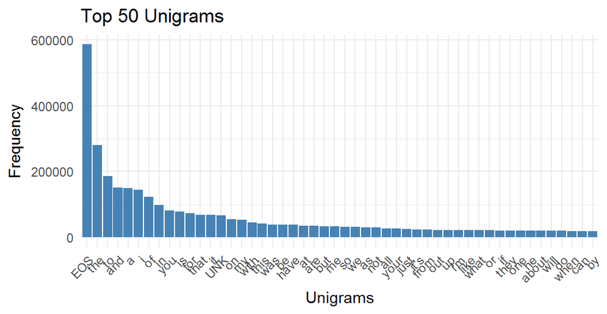

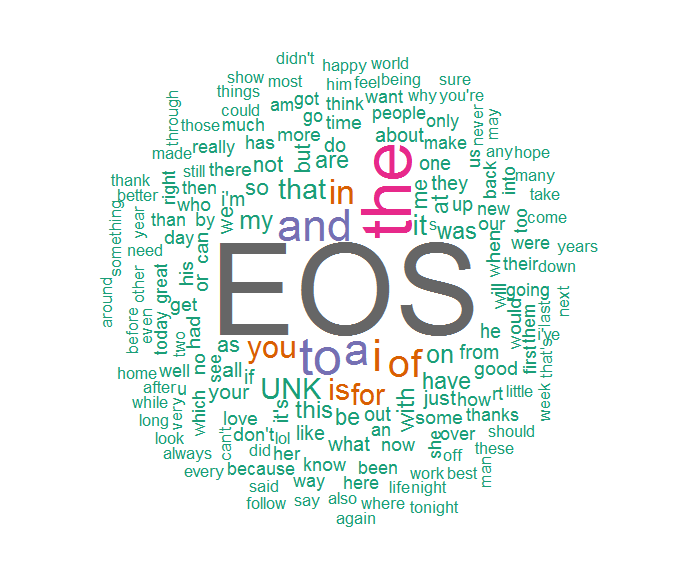

Figure 1: 50 Most frequent of $N$ = 62,812 unigrams

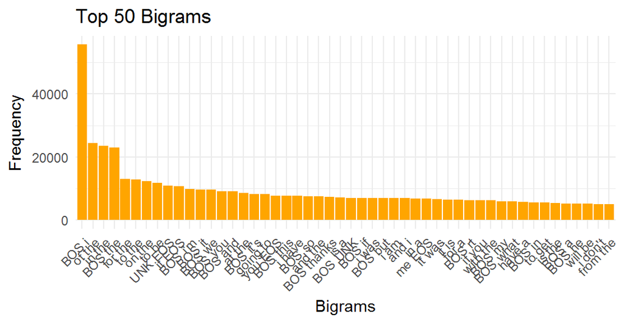

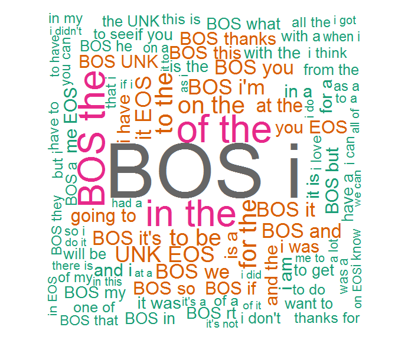

Figure 2: 50 Most frequent of $N$ = 1,623,575 bigrams

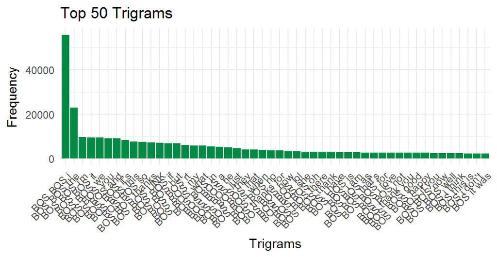

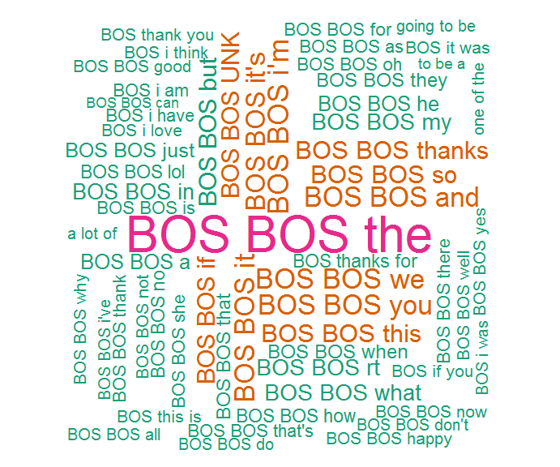

Figure 3: 50 Most frequent of $N$ = 4,080,442 trigrams

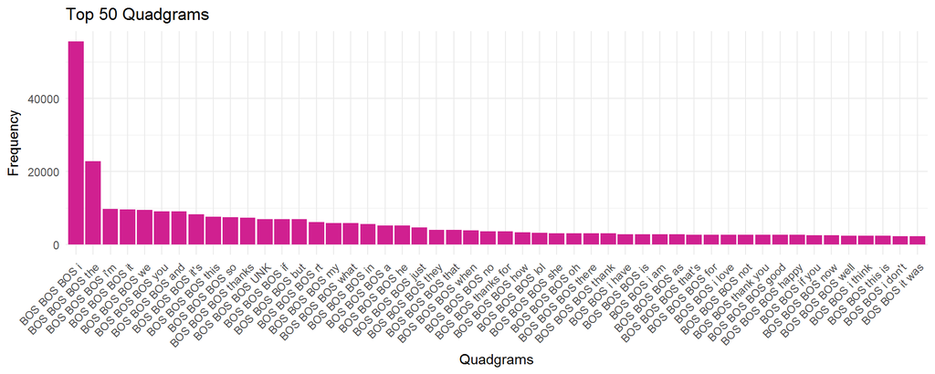

Figure 4: 50 Most frequent of $N$ = 5,383,454 quadgrams

#### Lexical Features

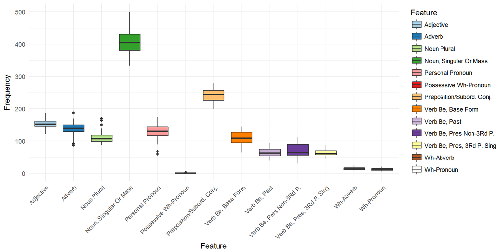

Figure 5: Grammatical Feature Distributions (per 2,000 words)

#### POS Based nGrams

The training corpus comprised some 41 POS unigrams, 1,281 POS bigrams, and 20,725 POS trigrams. The following reveals the top features by frequency for each Ngram.

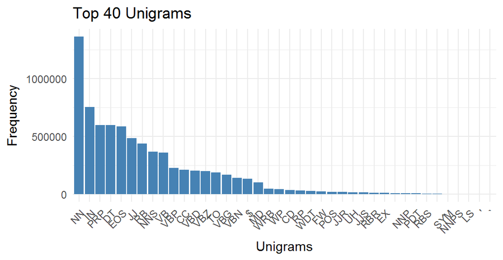

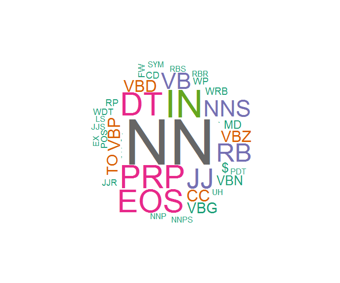

Figure 6: 40 Most frequent of $N$ = 41 unigrams

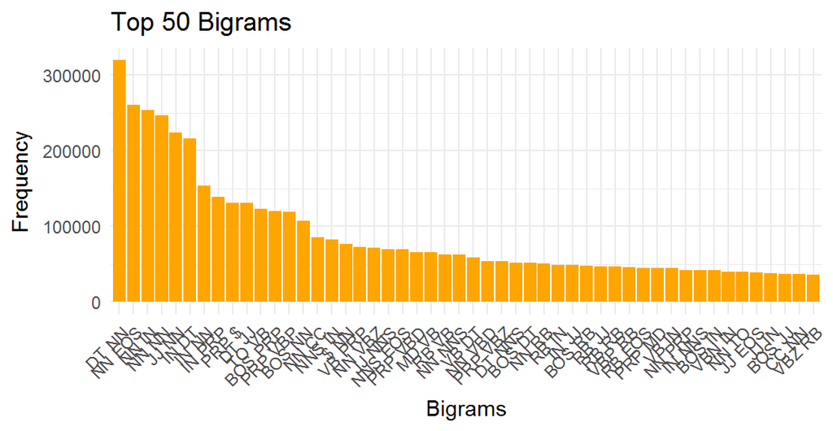

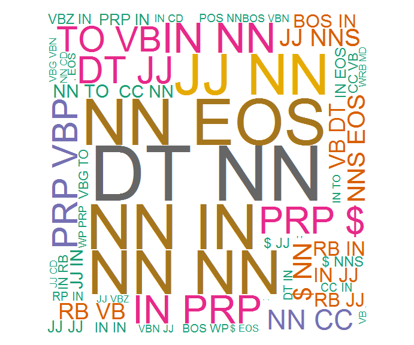

Figure 7: 50 Most frequent of $N$ = 1,281 bigrams

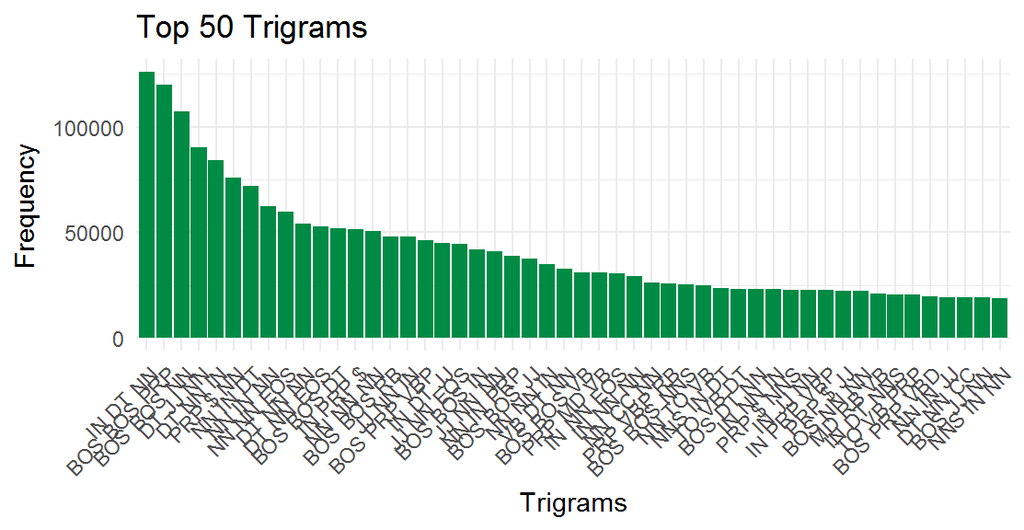

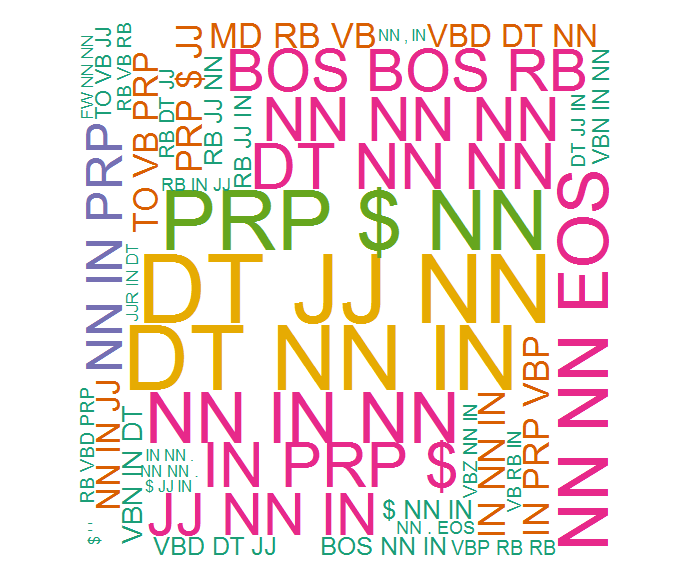

Figure 8: 50 Most frequent of $N$ = 20,725 trigrams